# CLASS-BIO Summary

Andrew McDevitt

May 17, 2017

## Load Data

Here is an example of the data that could be loaded in for each course.

```
##          ID PrePost Gender     Major Q1 Q2 Q3 Q4 Q5 Q6 Q7 Q8 Q9 Q10 Q11
## 1 Student 1     Pre   Male Chemistry  1  3  4  4  3  1  2  3  4   3   4
## 2 Student 2     Pre Female      Open  1  5  4  4  3  2  2  2  4   3   4
## 3 Student 3     Pre   Male Chemistry  3  4  5  5  5  1  1  2  5   3   2
## 4 Student 4     Pre Female       Bio  2  3  4  1  4  4  3  4  4   2   2
## 5 Student 5     Pre Female       Bio  5  2  4  1  4  5  3  5  4   1   1
## 6 Student 6     Pre Female       Bio  4  4  5  3  5  1  4  2  5   2   4
```

## Transform data

One thing that the CLASS-Bio excel spreadsheet did was convert the 5-item likert scale to a 3-item likert scale.

“To score student responses, each response was collapsed from a five-point Likert scale to a three-point scale:”neutral," “agree” (“strongly agree” or “agree”), or “disagree” (“strongly disagree” or “disagree”). Combining the “strongly agree”/“agree” and “strongly disagree”/“disagree” responses is consistent with an ordinal characterization of a Likert scale that assumes differencesbetween responses on the scale are not necessarily equal. Interviews from both the initial CLASS-Phys validation and our own interviews support this interpretation: student reasons for answering “agree” versus “strongly agree” or “disagree” versus “strongly disagree” were not consistent from student to student."

```
##          ID PrePost Gender     Major Q1 Q2 Q3 Q4 Q5 Q6 Q7 Q8 Q9 Q10 Q11
## 1 Student 1     Pre   Male Chemistry -1  0  1  1  0 -1 -1  0  1   0   1
## 2 Student 2     Pre Female      Open -1  1  1  1  0 -1 -1 -1  1   0   1
## 3 Student 3     Pre   Male Chemistry  0  1  1  1  1 -1 -1 -1  1   0  -1
## 4 Student 4     Pre Female       Bio -1  0  1 -1  1  1  0  1  1  -1  -1
## 5 Student 5     Pre Female       Bio  1 -1  1 -1  1  1  0  1  1  -1  -1
## 6 Student 6     Pre Female       Bio  1  1  1  0  1 -1  1 -1  1  -1   1
```

The next step is to compare how student responses compared to expert responses.

“Each student’s response is then designated as favorable (agreeing with the expert consensus-not necessarily agreeing with statement), unfavorable (disagreeing with expert consensus), or neutral (neither agreeing or disagreeing with the expert consensus). For example, for Statements 1 and 2 (Supplemental Material A), the expert response is”agree" and only students scoring “agree”/“strongly agree” are scored as having a favorable response. Meanwhile, for Statements 3 and 4 (Supplemental Material A), the expert consensus is “disagree” and, thus, only students answering “disagree”/“strongly disagree” are scored as having a favorable response."

```
##          ID          Q1          Q2          Q3          Q4          Q5
## 1 Student 1 unfavorable     netural unfavorable unfavorable     netural
## 2 Student 2 unfavorable   favorable unfavorable unfavorable     netural
## 3 Student 3     netural   favorable unfavorable unfavorable unfavorable
## 4 Student 4 unfavorable     netural unfavorable   favorable unfavorable
## 5 Student 5   favorable unfavorable unfavorable   favorable unfavorable
## 6 Student 6   favorable   favorable unfavorable     netural unfavorable
```

## Create graphs

From this data, we can then create graphs based upon the percentage of favorable or unfavorable responses.

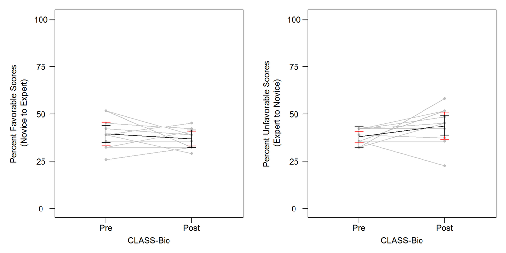

Figure 1. All questions relative to expert responses. Mean percentages are displayed in black and individual students are shown in gray. The regular between-subject 95% confidence intervals are in red, and the within-subject 95% confidence intervals are in black.

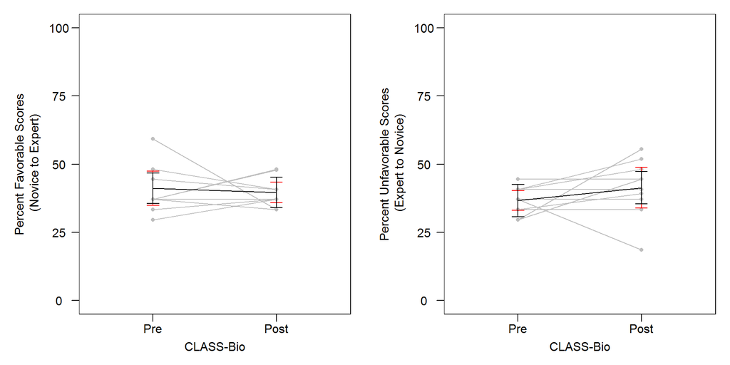

Figure 2. Categorized questions relative to expert responses. Mean percentages are displayed in black and individual students are shown in gray. The regular between-subject 95% confidence intervals are in red, and the within-subject 95% confidence intervals are in black.

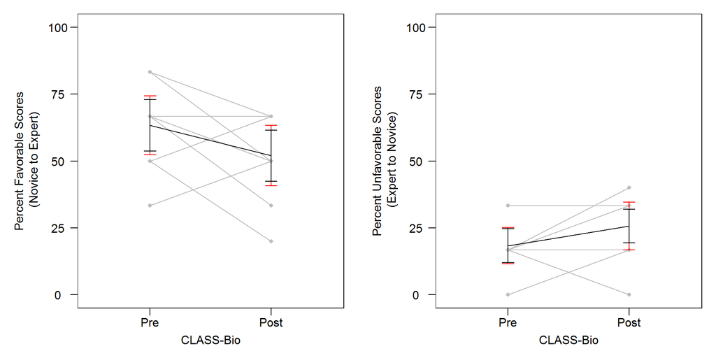

Figure 3. Enjoyment questions relative to expert responses. Mean percentages are displayed in black and individual students are shown in gray. The regular between-subject 95% confidence intervals are in red, and the within-subject 95% confidence intervals are in black.

Enjoyment questions:

1. My curiosity about the living world led me to study biology.
2. I think about the biology I experience in everyday life.
3. I want to study biology because I want to make a contribution to society.
4. I enjoy figuring out answers to biology questions.
5. If I had plenty of time, I would take a biology class outside of my major requirements just for fun.
6. I enjoy explaining biological ideas that I learn about to my friends.

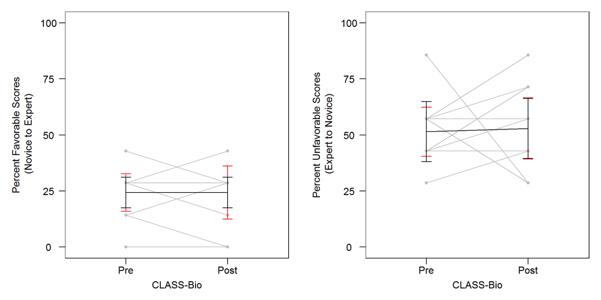

Figure 4. Problem-solving (Difficulty) questions relative to expert responses. Mean percentages are displayed in black and individual students are shown in gray. The regular between-subject 95% confidence intervals are in red, and the within-subject 95% confidence intervals are in black.

Problem-solving (Difficulty) questions:

3. After I study a topic in biology and feel that I understand it, I have difficulty applying that information to answer questions on the same topic.
4. When I am answering a biology question, I find it difficult to put what I know into my own words.
5. I do not expect the rules of biological principles to help my understanding of the ideas.
6. If I don’t remember a particular approach needed for a question on an exam, there’s nothing much I can do (legally!) to come up with it.
7. If I want to apply a method or idea used for understanding one biological problem to another problem, the problems must involve very similar situations.
8. If I get stuck on a biology question, there is no chance I’ll figure it out on my own.
9. I do not spend more than a few minutes stuck on a biology question before giving up or seeking help from someone else.

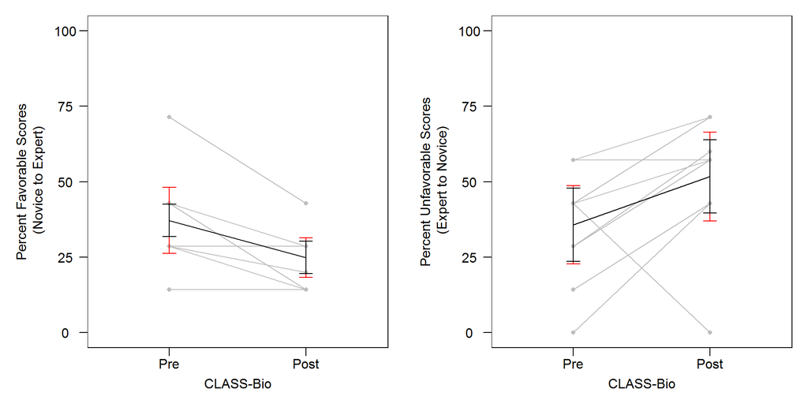

Figure 5. Problem-solving (Effort) questions relative to expert responses. Mean percentages are displayed in black and individual students are shown in gray. The regular between-subject 95% confidence intervals are in red, and the within-subject 95% confidence intervals are in black.

Problem-solving (Effort) questions:

8. If I get stuck on answering a biology question on my first try, I usually try to figure out a different way that works.
9. I enjoy figuring out answers to biology questions.
10. There are times I think about or solve a biology question in more than one way to help my understanding.
11. When studying biology, I relate the important information to what I already know rather than just memorizing it the way it is presented.
12. When I am not pressed for time, I will continue to work on a biology problem until I understand why something works the way it does.
13. I enjoy explaining biological ideas that I learn about to my friends.
14. I do not spend more than a few minutes stuck on a biology question before giving up or seeking help from someone else.

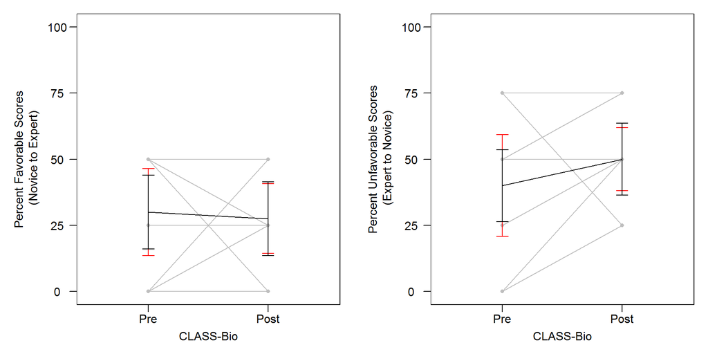

Figure 6. Problem-solving (Strategies) questions relative to expert responses. Mean percentages are displayed in black and individual students are shown in gray. The regular between-subject 95% confidence intervals are in red, and the within-subject 95% confidence intervals are in black.

Problem-solving (Strategies) questions:

7. To understand biology, I sometimes think about my personal experiences and relate them to the topic being analyzed.
8. If I get stuck on answering a biology question on my first try, I usually try to figure out a different way that works.
9. There are times I think about or solve a biology question in more than one way to help my understanding.
10. When studying biology, I relate the important information to what I already know rather than just memorizing it the way it is presented.

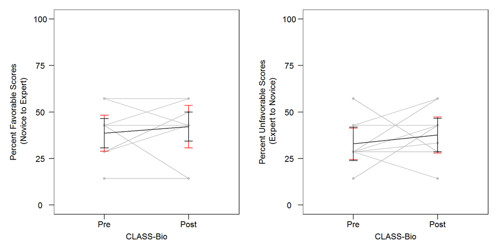

Figure 7. Real World Connections questions relative to expert responses. Mean percentages are displayed in black and individual students are shown in gray. The regular between-subject 95% confidence intervals are in red, and the within-subject 95% confidence intervals are in black.

Real World Connections questions:

2. I think about the biology I experience in everyday life.
3. I enjoy figuring out answers to biology questions.
4. Learning biology changes my ideas about how the natural world works.
5. Reasoning skills used to understand biology can be helpful to my everyday life.
6. It is a valuable use of my time to study the fundamental experiments behind biological ideas.
7. The subject of biology has little relation to what I experience in the real world.
8. Learning biology that is not directly relevant to or applicable to human health is not worth my time.

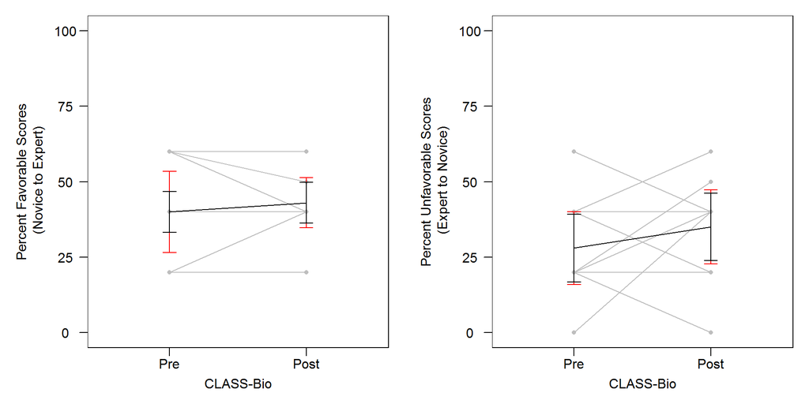

Figure 8. Reasoning questions relative to expert responses. Mean percentages are displayed in black and individual students are shown in gray. The regular between-subject 95% confidence intervals are in red, and the within-subject 95% confidence intervals are in black.

Reasoning questions:

8. If I get stuck on answering a biology question on my first try, I usually try to figure out a different way that works.
9. Learning biology changes my ideas about how the natural world works.
10. Reasoning skills used to understand biology can be helpful to my everyday life.
11. It is a valuable use of my time to study the fundamental experiments behind biological ideas.
12. When I am not pressed for time, I will continue to work on a biology problem until I understand why something works the way it does.